# Santander Bank Customers Satisfaction - Data Analytics Project

## 1.0 The Context and Understanding the Business

1. **The Context**

The Santander Bank provided an anonymized dataset with a large of numeric variables.  
 The "TARGET" column is the variable to predict. It equals one for unsatisfied customers and 0 for satisfied customers.

2. **The Business Chalenge**

Provide by Data Analytics Solution the probability that a customer will position yourself as unsatisfied.

3. **My Goals**

Provide this Data Analytics Solution using PySpark (Python + Spark) generating a predict model with the best accuracy and showing certain proficient level with Spark and Python Technologies passing per all project steps.

## 2.0 Business Context

### 2.1 Satisfied Customer, Profitable Business

For a bank or any other business that sells products or services, having a good number of satisfied customers makes all the difference.  
 The customer keeps the business! Your satisfaction with the products and/or services is what keeps the company competitive and alive in the market. Without a certain number of satisfied customers, it is impossible to keep up.  
 Customers are the source of profit for any business. Having customer feedback is important for the company to reduce the negative impacts of its activities. In the same way, seek to improve the solution offered in an effective, innovative and creative way.  
 Listening to the customer is very important for market expansion and brand credibility. Thus, the organization will show that it is always concerned with generating value for those who consume it.  
Para um banco ou qualquer outro negócio que venda produtos ou serviços, ter um número bom clientes satisfeitos faz toda a diferença.  
 O cliente é que mantém o negócio! Sua satisfação com os produtos e/ou serviços é que mantem a empresa competitiva e viva no mercado. Sem um certo número de clientes satisfeito, é impossível manter-se.  
 São os clientes a fonte de lucro de qualquer negócio. Ter um feedback do cliente é importante para que a empresa reduza os impactos negativos das suas atividades. Da mesma forma, busque aprimorar a solução oferecida de forma eficaz, inovadora e criativa.  
 Ouvir o cliente é muito importante para a expansão do mercado e credibilidade da marca. Assim, a organização mostrará que está sempre preocupado em gerar valor para quem o consome.

### 2.2 Net Promoter Score (NPS)

The NPS is a methodology that was created in the USA by the scholar Fred Reichheld. Its purpose is to measure the degree of satisfaction of any company's consumers.  
 In his book,The Ultimate Question, he shows you that you owe the customer a question.  
 Would you recommend our company to a friend or relative? From there, you can fit them into 3 large groups. They are: promoters, detractors and neutrals.  
 Promoters. Customers who answer YES and are customers who love your products. They will be the promoters, able to recommend your company to their friends.  
 Detractors. It's the customers who answer No. These are the people you need to be on the lookout for and act fast. Understand the reason for this negative feedback and act urgently!  
 There are also Neutrals, but let's focus on DETRACTORS!  
The NPS é uma metodologia que foi criada nos EUA pelo estudioso Fred Reichheld. Seu intuito é de mensurar o grau de satisfação dos consumidores de qualquer empresa.  
 Em seu livro, A Pergunta Definitiva ele mostra que você deve uma pergunta para o cliente.  
 Você recomendaria a nossa empresa para um amigo ou parente?  
 A partir daí, você consegue encaixá-los em 3 grandes grupos. São eles: promotores, detratores e neutros.  
Promotores. Os clientes que respondem SIM e são clientes que amam seus produtos. Eles serão os promotores, capazes de recomendar sua empresa para seus amigos.  
 Detratores. São os clientes que respondem Não.Estas são as pessoas que você precisa ficar atento e agir rápido. Entenda o motivo desse feedback negativo e ajir com urgência!  
 Existem também os Neutros, mas vamos manter o foco nos DETRATORES!

### Business Goal - Increase NPS

To find out your company's NPS, get the total percentage for each group, in this case, DETRACTORS AND PROMOTERS.  
 This is done by dividing the group total by the total number of registered ratings. Subtract the total percentage of “Detractors” from the total percentage of “Promoters”. So you will have your NPS.  
 NPS = % Promoters - % Detractors  
 Ideally, your score is always above or equal to 9. This will mean that your customers are promoters of your brand. NPS value can be classified in 3 ways.  
 0 to 6. Improvement zone, with a large volume of detractors and neutrals.  
 6 to 8. Quality zone. In other words, the company has more neutral customers and promoters than detractors.  
 8 to 10. Zone of perfection. In other words, the company has a high rate of promoting clients and few detractors.  
Para descobrir o NPS da sua empresa, obtenha o percentual total de cada grupo, neste caso, DETRATORES E PROMOTORES.  
 Isso se faz dividindo o total do grupo pelo total de avaliações resgistradas. Subtraia o percentual total de “Detratores” do percentual total de “Promotores”. Assim, você terá seu NPS.  
 NPS = % Promotores – % Detratores  
 O ideal é que seu resultado esteja sempre acima ou igual a 9. Isso irá significa que os seus clientes são promotores da sua marca.  
 Os valores do NPS podem ser classificados de 3 formas.  
 0 a 6. Zona de aperfeiçoamento, com grande volume de detratores e neutros.  
 6 a 8. Zona de qualidade. Em outras palavras, a empresa possui mais clientes neutros e promotores do que detratores.  
 8 a 10. Zona de perfeição. Ou seja, a empresa possui alto índice de clientes promotores e poucos detratores.

### Business Strategy

Using the database provided, generate a predictive model that generates a forecast of the probability of a customer to assess themselves as dissatisfied with the bank and with this information initiate Marketing actions and/or offers of new products and services to change this probability, increasing thus the NPS index.  
 By market statistics, 1 dissatisfied customer generates 3 more, and so on.  
 Taking this statistic to the opposite, in addition to keeping the current customer, we still have the possibility of raising more 3 customers for the organization with actions focused only on the current customer, which is much easier, profitable and with less investment.  
Usando a base de dados fornecida, gerar um modelo preditivo que gere uma previsão de probalilidade de um cliente avaliar como insatisfeito com o banco e com esta informação inicar ações de Marketing e/ou ofertas de novos produtos e serviços para mudar esta probalidade, aumentando assim o índice NPS.  
 Pelas estatísticas de mercado, 1 cliente insatisfeito geram mais 3 e assim por diante.  
 Levando esta estatítica para o inverso, além de mantermos o cliente atual, ainda temos a possibilidade de argariar mais 3 clientes para a organização com ações focadas apenas no cliente atual que é muito mais fácil, rentável e com menos investimento.

## 3.0 Development Environment Preparation

```python
# ↓↓ Print Spark Context started on Command Prompt Window as: pyspark (Windows Environment)
print(sc)
```

```
<SparkContext master=local[*] appName=PySparkShell>
```

```python
# Imports

# Auxiliar Libs
import math
import numpy as np
import matplotlib.pyplot as plt

# PySpark Libraries
from pyspark.ml.linalg import Vectors
from pyspark.sql import Row
from pyspark.ml.feature import StringIndexer
from pyspark.ml.feature import PCA
from pyspark.ml.classification import RandomForestClassifier
from pyspark.ml.evaluation import MulticlassClassificationEvaluator
from pyspark.ml.feature import MinMaxScaler
from pyspark.ml import Pipeline
from pyspark.ml.feature import VectorAssembler
from pyspark.ml.feature import StandardScaler
from pyspark.ml.tuning import ParamGridBuilder
from pyspark.ml.tuning import CrossValidator
from pyspark.ml.evaluation import BinaryClassificationEvaluator



# PySpark SQL Functions
import pyspark.sql.functions as f
```

## 4.0 Exploratory Data Analysis (EDA)

```python
# Loading Data from CSV File and
data_df = sqlContext.read.format("csv").load('./data/train.csv',header=True, inferSchema="true")
```

```python
# Printing Dataset First Line
data_df.head(1)
```

```
[Row(ID=1, var3=2, var15=23, imp_ent_var16_ult1=0.0, imp_op_var39_comer_ult1=0.0, imp_op_var39_comer_ult3=0.0, imp_op_var40_comer_ult1=0.0, imp_op_var40_comer_ult3=0.0, imp_op_var40_efect_ult1=0.0, imp_op_var40_efect_ult3=0.0, imp_op_var40_ult1=0.0, imp_op_var41_comer_ult1=0.0, imp_op_var41_comer_ul…
```

```python
# Printing Dataset Data Structure (Schema)
data_df.printSchema()
```

```
root
 |-- ID: integer (nullable = true)
 |-- var3: integer (nullable = true)
 |-- var15: integer (nullable = true)
 |-- imp_ent_var16_ult1: double (nullable = true)
 |-- imp_op_var39_comer_ult1: double (nullable = true)
 |-- imp_op_var39_comer_ult3: double (nullable = true)
 |-- imp_op_var40_comer_ult1: double (nullable = true)
 |-- imp_op_var40_comer_ult3: double (nullable = true)
 |-- imp_op_var40_efect_ult1: double (nullable = true)
 |-- imp_op_var40_efect_ult3: double (nullable = true)
 |-- imp_op_var40_ult1: double (nullable = true)
 |-- imp_op_var41_comer_ult1: double (nullable = true)
 |-- imp_op_var41_comer_ult3: double (nullable = true)
 |-- imp_op_var41_efect_ult1: double (nullable = true)
 |-- imp_op_var41_efect_ult3: double (nullable = true)
 |-- imp_op_var41_ult1: double (nullable = true)
 |-- imp_op_var39_efect_ult1: double (nullable = true)
 |-- imp_op_var39_efect_ult3: double (nullable = true)
 |-- imp_op_var39_ult1: double (nullable = true)
 |-- imp_sal_var16_ult1: double (nullable = true)
 |-- ind_var1_0: integer (nullable = true)
 |-- ind_var1: integer (nullable = true)
 |-- ind_var2_0: integer (nullable = true)
 |-- ind_var2: integer (nullable = true)
 |-- ind_var5_0: integer (nullable = true)
 |-- ind_var5: integer (nullable = true)
 |-- ind_var6_0: integer (nullable = true)
 |-- ind_var6: integer (nullable = true)
 |-- ind_var8_0: integer (nullable = true)
 |-- ind_var8: integer (nullable = true)
 |-- ind_var12_0: integer (nullable = true)
 |-- ind_var12: integer (nullable = true)
 |-- ind_var13_0: integer (nullable = true)
 |-- ind_var13_corto_0: integer (nullable = true)
 |-- ind_var13_corto: integer (nullable = true)
 |-- ind_var13_largo_0: integer (nullable = true)
 |-- ind_var13_largo: integer (nullable = true)
 |-- ind_var13_medio_0: integer (nullable = true)
 |-- ind_var13_medio: integer (nullable = true)
```

[output cut: 317 more lines]

```
 |-- saldo_medio_var17_ult3: double (nullable = true)
 |-- saldo_medio_var29_hace2: double (nullable = true)
 |-- saldo_medio_var29_hace3: double (nullable = true)
 |-- saldo_medio_var29_ult1: double (nullable = true)
 |-- saldo_medio_var29_ult3: double (nullable = true)
 |-- saldo_medio_var33_hace2: double (nullable = true)
 |-- saldo_medio_var33_hace3: double (nullable = true)
 |-- saldo_medio_var33_ult1: double (nullable = true)
 |-- saldo_medio_var33_ult3: double (nullable = true)
 |-- saldo_medio_var44_hace2: double (nullable = true)
 |-- saldo_medio_var44_hace3: double (nullable = true)
 |-- saldo_medio_var44_ult1: double (nullable = true)
 |-- saldo_medio_var44_ult3: double (nullable = true)
 |-- var38: double (nullable = true)
 |-- TARGET: integer (nullable = true)
```

```python
# Printing Dataset Dimensions
print("Number of Rows   : " + str(data_df.count()))
print("Number of Columns: " + str(len(data_df.columns)))
```

```
Number of Rows   : 76020
Number of Columns: 371
```

### 4.1 Checking Duplicated Data

```python
# Checking if there are more than one valuation per Client, verifying if exists duplicate Client IDs in Dataset
print("Number of Client IDs : " + str(data_df.select("ID").distinct().count()))
print("Number of Evaluations : " + str (data_df.count()))
```

```
Number of Client IDs : 76020
Number of Evaluations : 76020
```

#### ⬆ ⬆ Both numbers are the same showing there are no duplicated evaluations ⬆ ⬆

### 4.2 Checking Columns Statisticts

```python
# Printing Statistics Summary for each Column
```

```python
lstColumnsNames = data_df.columns
for name in lstColumnsNames:
   print(data_df.select(name).describe().show())
```

```
+-------+-----------------+
|summary|               ID|
+-------+-----------------+
|  count|            76020|
|   mean|75964.05072349381|
| stddev|43781.94737949353|
|    min|                1|
|    max|           151838|
+-------+-----------------+

None
+-------+-------------------+
|summary|               var3|
+-------+-------------------+
|  count|              76020|
|   mean|-1523.1992765061825|
| stddev|   39033.4623638633|
|    min|            -999999|
|    max|                238|
+-------+-------------------+

None
+-------+-----------------+
|summary|            var15|
+-------+-----------------+
|  count|            76020|
|   mean|33.21286503551697|
| stddev|12.95648581641122|
|    min|                5|
|    max|              105|
+-------+-----------------+

None
+-------+------------------+
|summary|imp_ent_var16_ult1|
+-------+------------------+
|  count|             76020|
|   mean| 86.20826519337017|
| stddev|1614.7573127238227|
|    min|               0.0|
```

[output cut: 4026 more lines]

```
|    max|     2.203473876E7|
+-------+------------------+

None
+-------+-------------------+
|summary|             TARGET|
+-------+-------------------+
|  count|              76020|
|   mean| 0.0395685345961589|
| stddev|0.19494451923252254|
|    min|                  0|
|    max|                  1|
+-------+-------------------+

None
```

#### ⬆ ⬆ There are columns with all values equal Zero! Let´s drop its! This process already reduces the number features. ⬆ ⬆

### 4.3 Feature Engeneering

```python
# Listing columns with 0 (zero) in all lines
for name in lstColumnsNames:
    if (data_df.select(f.avg(name)).collect()[0][0] == 0.00):
        print(name)
```

```
ind_var2_0
ind_var2
ind_var27_0
ind_var28_0
ind_var28
ind_var27
ind_var41
ind_var46_0
ind_var46
num_var27_0
num_var28_0
num_var28
num_var27
num_var41
num_var46_0
num_var46
saldo_var28
saldo_var27
saldo_var41
saldo_var46
imp_amort_var18_hace3
imp_amort_var34_hace3
imp_reemb_var13_hace3
imp_reemb_var33_hace3
imp_trasp_var17_out_hace3
imp_trasp_var33_out_hace3
num_var2_0_ult1
num_var2_ult1
num_reemb_var13_hace3
num_reemb_var33_hace3
num_trasp_var17_out_hace3
num_trasp_var33_out_hace3
saldo_var2_ult1
saldo_medio_var13_medio_hace3
```

```python
# Testing one listed for double check
data_df.select(f.avg("saldo_medio_var13_medio_hace3")).collect()[0][0]
```

```
0.0
```

```python
# Dropping the ID and all columns with Zero as value!
cols = ("ID","ind_var2_0","ind_var2","ind_var27_0","ind_var28_0","ind_var28","ind_var27","ind_var41", \
        "ind_var46_0","ind_var46","num_var27_0","num_var28_0","num_var28","num_var27","num_var41", \
        "num_var46_0","num_var46","saldo_var28","saldo_var27","saldo_var41","saldo_var46","imp_amort_var18_hace3" \
        "imp_amort_var34_hace3", "imp_reemb_var13_hace3", "imp_reemb_var33_hace3", "num_var2_0_ult1", \
        "num_var2_ult1", "num_reemb_var13_hace3","num_reemb_var33_hace3", "num_trasp_var17_out_hace3", \
        "num_trasp_var33_out_hace3","saldo_var2_ult1","saldo_medio_var13_medio_hace3","imp_amort_var18_hace3", \
        "imp_trasp_var33_out_hace3", "imp_trasp_var17_out_hace3", "imp_amort_var34_hace3"
       )

df_cln = data_df.drop(*cols)
```

```python
# Doble Check values with avg = 0.00
lstColumnsNames = df_cln.columns

for name in lstColumnsNames:
    if (df_cln.select(f.avg(name)).collect()[0][0] == 0.00):
        print(name)
```

#### ⬆ ⬆ No Columns Names were printed! ⬆ ⬆

```python
# Checking if theres Missing Values on columns in all Dataset
for name in lstColumnsNames:
    df_cln.select([f.count(f.when(f.isnan(name),True))]).show()
```

```
+------------------------------------------+
|count(CASE WHEN isnan(var3) THEN true END)|
+------------------------------------------+
|                                         0|
+------------------------------------------+

+-------------------------------------------+
|count(CASE WHEN isnan(var15) THEN true END)|
+-------------------------------------------+
|                                          0|
+-------------------------------------------+

+--------------------------------------------------------+
|count(CASE WHEN isnan(imp_ent_var16_ult1) THEN true END)|
+--------------------------------------------------------+
|                                                       0|
+--------------------------------------------------------+

+-------------------------------------------------------------+
|count(CASE WHEN isnan(imp_op_var39_comer_ult1) THEN true END)|
+-------------------------------------------------------------+
|                                                            0|
+-------------------------------------------------------------+

+-------------------------------------------------------------+
|count(CASE WHEN isnan(imp_op_var39_comer_ult3) THEN true END)|
+-------------------------------------------------------------+
|                                                            0|
+-------------------------------------------------------------+

+-------------------------------------------------------------+
|count(CASE WHEN isnan(imp_op_var40_comer_ult1) THEN true END)|
+-------------------------------------------------------------+
|                                                            0|
+-------------------------------------------------------------+

+-------------------------------------------------------------+
|count(CASE WHEN isnan(imp_op_var40_comer_ult3) THEN true END)|
+-------------------------------------------------------------+
|                                                            0|
```

[output cut: 1960 more lines]

```
+------------------------------------------------------------+
|                                                           0|
+------------------------------------------------------------+

+-------------------------------------------+
|count(CASE WHEN isnan(var38) THEN true END)|
+-------------------------------------------+
|                                          0|
+-------------------------------------------+

+--------------------------------------------+
|count(CASE WHEN isnan(TARGET) THEN true END)|
+--------------------------------------------+
|                                           0|
+--------------------------------------------+
```

#### 👆👆 No Columns with Missing Values! 👆👆

### 4.4 Showing Correlations between Target and Explanatory Variables

```python
# Showing Colums Correlation with Target Columns for First Line
for i in df_cln.columns:
    if not( isinstance(df_cln.select(i).take(1)[0][0], str)) :
        print( "TARGET Variable correlation with", i," is " ,df_cln.stat.corr('TARGET',i))
```

```
TARGET Variable correlation with var3  is  0.0044747981755366905
TARGET Variable correlation with var15  is  0.10132209856071672
TARGET Variable correlation with imp_ent_var16_ult1  is  -1.7460253766327273e-05
TARGET Variable correlation with imp_op_var39_comer_ult1  is  0.010353129575421522
TARGET Variable correlation with imp_op_var39_comer_ult3  is  0.003516922441689432
TARGET Variable correlation with imp_op_var40_comer_ult1  is  0.0031193869489658005
TARGET Variable correlation with imp_op_var40_comer_ult3  is  -0.000357869069980703
TARGET Variable correlation with imp_op_var40_efect_ult1  is  0.019221449288527075
TARGET Variable correlation with imp_op_var40_efect_ult3  is  0.019965206754799136
TARGET Variable correlation with imp_op_var40_ult1  is  0.0030872912147492096
TARGET Variable correlation with imp_op_var41_comer_ult1  is  0.010082404008577796
TARGET Variable correlation with imp_op_var41_comer_ult3  is  0.003858586978332241
TARGET Variable correlation with imp_op_var41_efect_ult1  is  0.029478518122528274
TARGET Variable correlation with imp_op_var41_efect_ult3  is  0.021485888881387187
TARGET Variable correlation with imp_op_var41_ult1  is  0.027586462000264347
TARGET Variable correlation with imp_op_var39_efect_ult1  is  0.030380260916655574
TARGET Variable correlation with imp_op_var39_efect_ult3  is  0.022171691020253202
TARGET Variable correlation with imp_op_var39_ult1  is  0.027416443434902363
TARGET Variable correlation with imp_sal_var16_ult1  is  0.0005094220620922702
TARGET Variable correlation with ind_var1_0  is  0.0016078192876507497
TARGET Variable correlation with ind_var1  is  0.009570907633960199
TARGET Variable correlation with ind_var5_0  is  -0.03288776753995667
TARGET Variable correlation with ind_var5  is  -0.1353485022021018
TARGET Variable correlation with ind_var6_0  is  -0.0020823115452682428
TARGET Variable correlation with ind_var6  is  -0.0010411146833006354
TARGET Variable correlation with ind_var8_0  is  0.04666549435362123
TARGET Variable correlation with ind_var8  is  0.027926030196463895
TARGET Variable correlation with ind_var12_0  is  -0.03821493590236842
TARGET Variable correlation with ind_var12  is  -0.03425468897398665
TARGET Variable correlation with ind_var13_0  is  -0.03947067316626937
TARGET Variable correlation with ind_var13_corto_0  is  -0.03433671323042939
TARGET Variable correlation with ind_var13_corto  is  -0.034438144445046164
TARGET Variable correlation with ind_var13_largo_0  is  -0.0192272921256072
TARGET Variable correlation with ind_var13_largo  is  -0.01904046778216914
TARGET Variable correlation with ind_var13_medio_0  is  -0.0010411146833006338
TARGET Variable correlation with ind_var13_medio  is  -0.0010411146833006338
TARGET Variable correlation with ind_var13  is  -0.03961192773482279
TARGET Variable correlation with ind_var14_0  is  -0.0200462369936246
TARGET Variable correlation with ind_var14  is  -0.007383880693568438
TARGET Variable correlation with ind_var17_0  is  -0.005442498400165837
```

[output cut: 281 more lines]

```
TARGET Variable correlation with saldo_medio_var17_ult3  is  -0.0003275874658176671
TARGET Variable correlation with saldo_medio_var29_hace2  is  -0.0010341425774526693
TARGET Variable correlation with saldo_medio_var29_hace3  is  -0.0007361744104648032
TARGET Variable correlation with saldo_medio_var29_ult1  is  -0.0009895969145222658
TARGET Variable correlation with saldo_medio_var29_ult3  is  -0.0011882705549470143
TARGET Variable correlation with saldo_medio_var33_hace2  is  -0.003533289812853347
TARGET Variable correlation with saldo_medio_var33_hace3  is  -0.002431491172026585
TARGET Variable correlation with saldo_medio_var33_ult1  is  -0.0031657888885731943
TARGET Variable correlation with saldo_medio_var33_ult3  is  -0.0033113414559340906
TARGET Variable correlation with saldo_medio_var44_hace2  is  -0.003176565235132094
TARGET Variable correlation with saldo_medio_var44_hace3  is  -0.0025526409090075174
TARGET Variable correlation with saldo_medio_var44_ult1  is  -0.0031036790276660247
TARGET Variable correlation with saldo_medio_var44_ult3  is  -0.003014738103251638
TARGET Variable correlation with var38  is  -0.019509837571079394
TARGET Variable correlation with TARGET  is  1.0
```

## 5.0 Dimensionality Reduction

```python
# Printing Dataset Dimension

print((df_cln.count(), len(df_cln.columns)))
```

```
(76020, 336)
```

#### 👉 Due exist too many columns in the dataset, it seems to be necessary to apply a dimension reduction to this data structure in order to use it later in the prediction model.

#### 👌 Let´s user Spark ML PCA for it!

```python
# Creating a Function to Create LabeledPoint Object (target, Vector[features]) based on Dataset
def transformaVar3(row) :
    obj = (row["TARGET"], Vectors.dense(
	[
	row["var3"],
	row["var15"],
	row["imp_ent_var16_ult1"]
    ,row["imp_op_var39_comer_ult1"], row["imp_op_var39_comer_ult3"]
    ,row["imp_op_var40_comer_ult1"], row["imp_op_var40_comer_ult3"]
    ,row["imp_op_var40_efect_ult1"], row["imp_op_var40_efect_ult3"]
    ,row["imp_op_var40_ult1"], row["imp_op_var41_comer_ult1"], row["imp_op_var41_comer_ult3"]
    ,row["imp_op_var41_efect_ult1"], row["imp_op_var41_efect_ult3"]
	,row["imp_op_var41_ult1"]
	,row["imp_op_var39_efect_ult1"], row["imp_op_var39_efect_ult3"], row["imp_op_var39_ult1"]
	,row["imp_sal_var16_ult1"]

    ,row["ind_var1_0"], row["ind_var1"]
	,row["ind_var5_0"], row["ind_var5"]
	,row["ind_var6_0"], row["ind_var6"]
	,row["ind_var8_0"], row["ind_var8"]
	,row["ind_var12_0"], row["ind_var12"]

    ,row["ind_var13_0"]
	,row["ind_var13_corto_0"], row["ind_var13_corto"]
	,row["ind_var13_largo_0"], row["ind_var13_largo"]
	,row["ind_var13_medio_0"], row["ind_var13_medio"]

    ,row["ind_var13"]
	,row["ind_var14_0"], row["ind_var14"]
	,row["ind_var17_0"], row["ind_var17"]
	,row["ind_var18_0"], row["ind_var18"]
	,row["ind_var19"]

    ,row["ind_var20_0"], row["ind_var20"]
	,row["ind_var24_0"], row["ind_var24"]
	,row["ind_var25_cte"]
	,row["ind_var26_0"], row["ind_var26_cte"], row["ind_var26"]
	,row["ind_var25_0"], row["ind_var25"]
	,row["ind_var29_0"], row["ind_var29"]
	,row["ind_var30_0"], row["ind_var30"]
	,row["ind_var31_0"], row["ind_var31"]

    ,row["ind_var32_cte"], row["ind_var32_0"], row["ind_var32"]
	,row["ind_var33_0"], row["ind_var33"]
	,row["ind_var34_0"], row["ind_var34"]
	,row["ind_var37_cte"], row["ind_var37_0"], row["ind_var37"]
	,row["ind_var39_0"]
	,row["ind_var40_0"], row["ind_var40"]
	,row["ind_var41_0"]
	,row["ind_var39"]

    ,row["ind_var44_0"], row["ind_var44"]
	,row["num_var1_0"], row["num_var1"]
	,row["num_var4"]
	,row["num_var5_0"], row["num_var5"]
	,row["num_var6_0"], row["num_var6"]
	,row["num_var8_0"], row["num_var8"]
	,row["num_var12_0"], row["num_var12"]

    ,row["num_var13_0"]
	,row["num_var13_corto_0"], row["num_var13_corto"]
	,row["num_var13_largo_0"], row["num_var13_largo"]
	,row["num_var13_medio_0"], row["num_var13_medio"]
	,row["num_var13"]


    ,row["num_var14_0"], row["num_var14"]
	,row["num_var17_0"], row["num_var17"]
	,row["num_var18_0"], row["num_var18"]
	,row["num_var20_0"], row["num_var20"]
	,row["num_var24_0"], row["num_var24"]
	,row["num_var26_0"], row["num_var26"]


    ,row["num_var25_0"], row["num_var25"]
	,row["num_op_var40_hace2"], row["num_op_var40_hace3"], row["num_op_var40_ult1"], row["num_op_var40_ult3"]
	,row["num_op_var41_hace2"], row["num_op_var41_hace3"], row["num_op_var41_ult1"], row["num_op_var41_ult3"]
	,row["num_op_var39_hace2"], row["num_op_var39_hace3"], row["num_op_var39_ult1"], row["num_op_var39_ult3"]
	,row["num_var29_0"], row["num_var29"]
	,row["num_var30_0"], row["num_var30"]
	,row["num_var31_0"], row["num_var31"]
	,row["num_var32_0"], row["num_var32"]

    ,row["num_var33_0"], row["num_var33"]
	,row["num_var34_0"], row["num_var34"]
	,row["num_var35"]
	,row["num_var37_med_ult2"], row["num_var37_0"], row["num_var37"]
	,row["num_var39_0"]
	,row["num_var40_0"], row["num_var40"]
	,row["num_var41_0"]
	,row["num_var39"]

    ,row["num_var42_0"], row["num_var42"]
	,row["num_var44_0"], row["num_var44"]
	,row["saldo_var1"], row["saldo_var5"], row["saldo_var6"], row["saldo_var8"], row["saldo_var12"]
	,row["saldo_var13_corto"], row["saldo_var13_largo"], row["saldo_var13_medio"], row["saldo_var13"]
	,row["saldo_var14"], row["saldo_var17"], row["saldo_var18"], row["saldo_var20"], row["saldo_var24"], row["saldo_var26"], row["saldo_var25"]
	,row["saldo_var29"], row["saldo_var30"], row["saldo_var31"], row["saldo_var32"], row["saldo_var33"], row["saldo_var34"]
	,row["saldo_var37"], row["saldo_var40"], row["saldo_var42"], row["saldo_var44"], row["var36"]

    ,row["delta_imp_amort_var18_1y3"], row["delta_imp_amort_var34_1y3"]
	,row["delta_imp_aport_var13_1y3"], row["delta_imp_aport_var17_1y3"], row["delta_imp_aport_var33_1y3"]
	,row["delta_imp_compra_var44_1y3"]
	,row["delta_imp_reemb_var13_1y3"], row["delta_imp_reemb_var17_1y3"], row["delta_imp_reemb_var33_1y3"]
	,row["delta_imp_trasp_var17_in_1y3"], row["delta_imp_trasp_var17_out_1y3"], row["delta_imp_trasp_var33_in_1y3"], row["delta_imp_trasp_var33_out_1y3"]
	,row["delta_imp_venta_var44_1y3"]

    ,row["delta_num_aport_var13_1y3"], row["delta_num_aport_var17_1y3"], row["delta_num_aport_var33_1y3"]
	,row["delta_num_compra_var44_1y3"]
	,row["delta_num_reemb_var13_1y3"], row["delta_num_reemb_var17_1y3"], row["delta_num_reemb_var33_1y3"]
	,row["delta_num_trasp_var17_in_1y3"], row["delta_num_trasp_var17_out_1y3"], row["delta_num_trasp_var33_in_1y3"] ,row["delta_num_trasp_var33_out_1y3"]
	,row["delta_num_venta_var44_1y3"]
	,row["imp_amort_var18_ult1"], row["imp_amort_var34_ult1"]
	,row["imp_aport_var13_hace3"], row["imp_aport_var13_ult1"]
	,row["imp_aport_var17_hace3"], row["imp_aport_var17_ult1"]

    ,row["imp_aport_var33_hace3"], row["imp_aport_var33_ult1"]
	,row["imp_var7_emit_ult1"], row["imp_var7_recib_ult1"]
	,row["imp_compra_var44_hace3"], row["imp_compra_var44_ult1"]
	,row["imp_reemb_var13_ult1"], row["imp_reemb_var17_hace3"], row["imp_reemb_var17_ult1"], row["imp_reemb_var33_ult1"]
	,row["imp_var43_emit_ult1"]
	,row["imp_trans_var37_ult1"]
	,row["imp_trasp_var17_in_hace3"], row["imp_trasp_var17_in_ult1"], row["imp_trasp_var17_out_ult1"]
	,row["imp_trasp_var33_in_hace3"], row["imp_trasp_var33_in_ult1"], row["imp_trasp_var33_out_ult1"]

    ,row["imp_venta_var44_hace3"], row["imp_venta_var44_ult1"], row["ind_var7_emit_ult1"]
	,row["ind_var7_recib_ult1"]
	,row["ind_var10_ult1"], row["ind_var10cte_ult1"]
	,row["ind_var9_cte_ult1"], row["ind_var9_ult1"]
	,row["ind_var43_emit_ult1"], row["ind_var43_recib_ult1"]
	,row["var21"]
	,row["num_aport_var13_hace3"], row["num_aport_var13_ult1"]
	,row["num_aport_var17_hace3"], row["num_aport_var17_ult1"]
	,row["num_aport_var33_hace3"], row["num_aport_var33_ult1"]
	,row["num_var7_emit_ult1"], row["num_var7_recib_ult1"]


    ,row["num_compra_var44_hace3"], row["num_compra_var44_ult1"]
	,row["num_ent_var16_ult1"]
	,row["num_var22_hace2"],row["num_var22_hace3"], row["num_var22_ult1"], row["num_var22_ult3"]
	,row["num_med_var22_ult3"], row["num_med_var45_ult3"]
	,row["num_meses_var5_ult3"],row["num_meses_var8_ult3"], row["num_meses_var12_ult3"]
	,row["num_meses_var13_corto_ult3"], row["num_meses_var13_largo_ult3"], row["num_meses_var13_medio_ult3"]
	,row["num_meses_var17_ult3"],row["num_meses_var29_ult3"], row["num_meses_var33_ult3"]
	,row["num_meses_var39_vig_ult3"],row["num_meses_var44_ult3"]

    ,row["num_op_var39_comer_ult1"],row["num_op_var39_comer_ult3"]
	,row["num_op_var40_comer_ult1"],row["num_op_var40_comer_ult3"], row["num_op_var40_efect_ult1"]
	,row["num_op_var40_efect_ult3"]
	,row["num_op_var41_comer_ult1"],row["num_op_var41_comer_ult3"], row["num_op_var41_efect_ult1"]
	,row["num_op_var41_efect_ult3"]

    ,row["num_op_var39_efect_ult1"],row["num_op_var39_efect_ult3"]
	,row["num_reemb_var13_ult1"],row["num_reemb_var17_hace3"], row["num_reemb_var17_ult1"]
	,row["num_reemb_var33_ult1"]
	,row["num_sal_var16_ult1"]
	,row["num_var43_emit_ult1"],row["num_var43_recib_ult1"]
	,row["num_trasp_var11_ult1"]
	,row["num_trasp_var17_in_hace3"],row["num_trasp_var17_in_ult1"], row["num_trasp_var17_out_ult1"]
	,row["num_trasp_var33_in_hace3"],row["num_trasp_var33_in_ult1"], row["num_trasp_var33_out_ult1"]


    ,row["num_venta_var44_hace3"],row["num_venta_var44_ult1"]
	,row["saldo_medio_var5_hace2"],row["saldo_medio_var5_hace3"], row["saldo_medio_var5_ult1"]
	,row["saldo_medio_var5_ult3"]
	,row["saldo_medio_var8_hace2"],row["saldo_medio_var8_hace3"], row["saldo_medio_var8_ult1"]
	,row["saldo_medio_var8_ult3"]
	,row["saldo_medio_var12_hace2"],row["saldo_medio_var12_hace3"], row["saldo_medio_var12_ult1"]
	,row["saldo_medio_var12_ult3"]

   	,row["saldo_medio_var13_corto_hace2"],row["saldo_medio_var13_corto_hace3"], row["saldo_medio_var13_corto_ult1"]
	,row["saldo_medio_var13_corto_ult3"]
	,row["saldo_medio_var13_largo_hace2"],row["saldo_medio_var13_largo_hace3"], row["saldo_medio_var13_largo_ult1"]
	,row["saldo_medio_var13_largo_ult3"]
	,row["saldo_medio_var13_medio_hace2"],row["saldo_medio_var13_medio_ult1"], row["saldo_medio_var13_medio_ult3"]
	,row["saldo_medio_var17_hace2"],row["saldo_medio_var17_hace3"], row["saldo_medio_var17_ult1"]
	,row["saldo_medio_var17_ult3"]

    ,row["saldo_medio_var29_hace2"],row["saldo_medio_var29_hace3"], row["saldo_medio_var29_ult1"]
	,row["saldo_medio_var29_ult3"]
	,row["saldo_medio_var33_hace2"],row["saldo_medio_var33_hace3"], row["saldo_medio_var33_ult1"]
	,row["saldo_medio_var33_ult3"]
	,row["saldo_medio_var44_hace2"],row["saldo_medio_var44_hace3"], row["saldo_medio_var44_ult1"]
	,row["saldo_medio_var44_ult3"]
	,row["var38"]

]
                                        ))
    return obj
```

```python
# Calling Fucntion to Create a LabeledPoint Object
bankRDD4 = df_cln.rdd.map(transformaVar3) ; bankRDD4.collect()
```

[output not shown]

[output cut: 1975 more lines]

```python
# Getting Corrent Spark Session
ss = SparkSession.builder.getOrCreate()
```

```python
# Converting LabeledPoint in a Spark DataFrame
bankDF = ss.createDataFrame(bankRDD4,["label", "features"])

bankDF.select("features", "label").show(10)
```

```
+--------------------+-----+
|            features|label|
+--------------------+-----+
|[2.0,23.0,0.0,0.0...|    0|
|[2.0,34.0,0.0,0.0...|    0|
|[2.0,23.0,0.0,0.0...|    0|
|[2.0,37.0,0.0,195...|    0|
|[2.0,39.0,0.0,0.0...|    0|
|[2.0,23.0,0.0,0.0...|    0|
|[2.0,27.0,0.0,0.0...|    0|
|[2.0,26.0,0.0,0.0...|    0|
|[2.0,45.0,0.0,0.0...|    0|
|[2.0,25.0,0.0,0.0...|    0|
+--------------------+-----+
only showing top 10 rows
```

#### 👉 Let´s start with 50 (K= 50) and see the result in order to look for a Best PCA Number of Components

```python
PCABestCompsNum = PCA(k = 50, inputCol = "features", outputCol = "pcaFeatures")
PCABestCompsNum_Model = PCABestCompsNum.fit(bankDF)
```

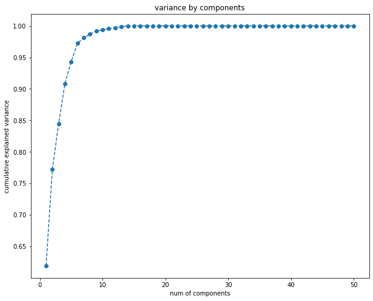

```python
# Plotting a Graphic in order to show all number of K-components generated
cumValues = PCABestCompsNum_Model.explainedVariance.cumsum()
plt.figure(figsize=(10,8))
plt.plot(range(1,51), cumValues, marker = 'o', linestyle='--')
plt.title('variance by components')
plt.xlabel('num of components')
plt.ylabel('cumulative explained variance')
```

### 5.1 Dimensionality Reduction RESULT by PCA Strategy

### As observed 👆👆, after number 20 of components, we heave 100% as cumulative explained variance. So, 20 will be number of components standard from now on.

## 6.0 Modeling

### 6.1 Model Version 1 - Without Target Variable Balance and Without Scale/Standardization

```python
# Applying Dimensionality Reduction with PCA with 20 as number of components, following recommendation in previous step.
bankPCA = PCA(k = 20, inputCol = "features", outputCol = "pcaFeatures")
pcaModel = bankPCA.fit(bankDF)
pcaResult = pcaModel.transform(bankDF).select("label","pcaFeatures")
pcaResult.show(truncate = False)
```

```
+-----+-----------------------------------------------------------------------------------------------------------------------------------------------------------------------------------------------------------------------------------------------------------------------------------------------------…
|label|pcaFeatures                                                                                                                                                                                                                                                                                          …
+-----+-----------------------------------------------------------------------------------------------------------------------------------------------------------------------------------------------------------------------------------------------------------------------------------------------------…
|0    |[-0.04231944266142465,0.07495952291265322,-0.03478612830668911,-0.06877044735251281,0.2149518441076603,-0.10553793219172465,0.0885631165261385,-0.04809055665538894,0.11548898246484902,-0.9018183733186294,-0.3329067438060113,0.07103911519736003,0.6896055950488366,-0.18169384933374702,-39194.14…
|0    |[1.351394514466051,0.09904855048991615,-0.04958469085868704,-0.12390789138983338,0.26666400969729126,-0.128431383201092,0.11250375591494455,-0.054237815528851194,0.14654469807251924,-1.1337060420144767,-0.4183938008353284,0.089356294044279,0.8650151507314384,-0.2222554476282062,-49275.9989406…
|0    |[-0.07271947461949446,0.12875801361311778,-0.059805592232376005,-0.11813088898647621,0.36918224157825613,-0.18124448338693644,0.1521192435219565,-0.08251847562952554,0.19840886417813164,-1.5488492831360052,-0.5717552864917209,0.12200966342517024,1.184372561816091,-0.3119767755336089,-67314.92…
|0    |[-0.07027623077346622,0.12295620770842317,-0.05880543110436311,-0.11285576067101571,0.35117144007917533,-0.17215136787558996,0.14497109560160903,-0.07619969523561611,0.19086689178269195,-1.4726173515925758,-0.5433929869058347,0.11602231444518986,1.1259758726742164,-0.2942185108749682,-63992.7…
|0    |[-2.6111528519941585,1.5647707488521758,-5.43315932556921,-2.298808275395983,1.58906919772058,1.860077425368978,1.6767039641811634,7.1764130056465945,4.312050630415869,-2.8023320582414883,-0.895556275339738,0.3676098169701727,1.376723907880771,6.525223463813746,-123221.61896898103,-298112.509…
|0    |[-0.09496416768452963,0.16820796342276162,-0.07805953118731868,-0.15431978492999465,0.4823483652161337,-0.23682535803071103,0.19873412707782884,-0.10791442277883134,0.25915533942375035,-2.0236649358296566,-0.7470371181111382,0.15941056376371626,1.5474632541077278,-0.40771791630897036,-87951.0…
|0    |[-0.10253698122454186,0.18157277353579185,-0.08431590181621022,-0.16658496700406988,0.5206314768388307,-0.25560357423478236,0.21451830411864958,-0.11640097284740084,0.2797798635561376,-2.184245140839171,-0.8063122076534275,0.17206185390488096,1.6702500428421685,-0.43999218138693286,-94930.046…
|0    |[-0.2716662925329651,0.48114676408468054,-0.22333838077810006,-0.44142429054731946,1.37968000880174,-0.6773830382660307,0.5684581439079561,-0.30859307972118516,0.7413291570407354,-5.788333617673298,-2.1367637328802322,0.4559674835940338,4.42623745863762,-1.16612551016612,-251568.26756584682,5…
|0    |[-0.11006147763812815,0.19494947275251523,-0.09046936371007497,-0.1788533526449218,0.5590314732244768,-0.27447556515237315,0.23032859815300646,-0.1250705129787007,0.3003555224545414,-2.345384500559651,-0.8658001503789352,0.18475346701878648,1.793476969934622,-0.4725363605381546,-101933.342154…
|0    |[-0.3848170445533089,0.681568430013685,-0.3163469092870954,-0.6252980401732561,1.9544035848703483,-0.9595630285506864,0.8052520489553674,-0.4371746648696814,1.05011514324741,-8.199553018908793,-3.0268669300669515,0.6459069769224095,6.270057340470515,-1.651926314565384,-356362.8937856599,7447.…
|0    |[-0.265271657169192,0.2964230857078711,-0.2954593557896378,-0.2849042009786797,0.7444581425854992,-0.24941491288927473,0.3330164276496512,0.10505865012310256,0.49827627718639644,-2.9232748459328564,-1.0610294902086266,0.2344465648568418,2.196514729425863,-0.322438116947572,-125681.00977209472…
|0    |[-0.08135547183431972,0.14410317744481507,-0.0668733288740114,-0.13220522018962935,0.41322617142592516,-0.20288746698939686,0.1702548393338611,-0.09244990960029872,0.2220174838603586,-1.7336667950912379,-0.6399841262099492,0.13656648398044377,1.3257064401102758,-0.34929053104738556,-75347.321…
|0    |[-0.1330495877523331,0.23420344602094428,-0.11035545861342197,-0.2149854249560619,0.6703651262270063,-0.3285797201470154,0.27654444707414916,-0.14756490289397786,0.36189445413046795,-2.8114300954441926,-1.0377397330705909,0.2215198867121266,2.149646268082593,-0.5640215486836533,-122188.593659…
```

[output cut: 9 more lines]

```python
# Indexing is pre-requisit for Decision Trees in Random Forest
stringIndexer = StringIndexer(inputCol = "label", outputCol = "indexed")
si_model = stringIndexer.fit(pcaResult)
si_model_final = si_model.transform(pcaResult)
si_model_final.collect()
```

[output not shown]

[output cut: 984 more lines]

```python
# Creating Training and Test Data
(train_data, test_data) = si_model_final.randomSplit([0.8, 0.2])
```

```python
# Print Rows Number of Train Data
train_data.count()
```

```
60858
```

```python
# Print Rows Number of Test Data
test_data.count()
```

```
15162
```

```python
# Creating 1st Model with Random Forest and Training Model
rfClassifer = RandomForestClassifier(labelCol = "indexed", featuresCol = "pcaFeatures")
model_V1 = rfClassifer.fit(train_data)
```

```python
# Getting Predections using Test Data
predictions = model_V1.transform(test_data)
predictions.select("prediction", "indexed", "label", "pcaFeatures").collect()
```

[output not shown]

[output cut: 984 more lines]

```python
# Evaluating 1st Model Accuracy
evaluator = MulticlassClassificationEvaluator(predictionCol = "prediction", labelCol = "indexed", metricName = "accuracy")
evaluator.evaluate(predictions)
```

```
0.9595699775755178
```

### Model Version 1 Accuracy

### As observed 👆👆, The 1st Model Accuracy is excellent, but we must check the target variable values balance!

```python
# Printing 1st Model Confusion Matrix
predictions.groupBy("indexed", "prediction").count().show()
```

```
+-------+----------+-----+
|indexed|prediction|count|
+-------+----------+-----+
|    1.0|       0.0|  613|
|    0.0|       0.0|14549|
+-------+----------+-----+
```

## 7.0 Target Variable Balancing

```python
# Let´s check now the balance of target values in Dataset
```

```python
# Check Target Column Balance
df_cln.groupBy('TARGET').count().show()
```

```
+------+-----+
|TARGET|count|
+------+-----+
|     1| 3008|
|     0|73012|
+------+-----+
```

### As observed 👆👆, it seems be unbalanced. With this way, the model will learn more about Good Evaluation (TARGET = 0) than Bad Evaluation (TARGET = 1). Our goal is to have a model with Balancing Learning. There is a need to apply a oversample strategy in order to ballance target values in dataset

```python
# Getting rows witn Target = 0
major_class_0 = df_cln.filter(f.col("TARGET") == 0)
```

```python
# Getting rows witn Target = 0
minor_class_1 = df_cln.filter(f.col("TARGET") == 1)
```

```python
# Showing rows number witn Target = 1 (Bad Evaluation)
minor_class_1.count()
```

```
3008
```

```python
# Showing rows number witn Target = 0 (Good Evaluation)
major_class_0.count()
```

```
73012
```

```python
# major_class_0.count() /  minor_class_1.count() = 24X more with Target = 0
a = range(24)
oversampled_df = minor_class_1.withColumn("dummy", f.explode(f.array([f.lit(x) for x in a]))).drop('dummy')
```

```python
# 72192 Samples with Target = 0 created
oversampled_df.count()
```

```
72192
```

```python
# combine both oversampled minority rows and previous majority rows
combined_df = major_class_0.unionAll(oversampled_df)
combined_df.count()
```

```
145204
```

```python
combined_df.groupBy('TARGET').count().show()
```

```
+------+-----+
|TARGET|count|
+------+-----+
|     1|72192|
|     0|73012|
+------+-----+
```

### As observed 👆👆, NOW it seems be balanced. With this way, the model will learn balanced about Good Evaluation (TARGET = 0) and Bad Evaluation (TARGET = 1).

## 7.0 New Training and Test Data With Dataset Balanced on Target Variable

```python
# Calling Function to Create a LabeledPoint Object, now with a new Train Dataset Balanced
bankRDD4_Balanced = combined_df.rdd.map(transformaVar3)
```

```python
# Converting Balanced LabeledPoint in a Spark DataFrame
bankDF_Balanced = ss.createDataFrame(bankRDD4_Balanced,["label", "features"])
bankDF_Balanced.select("features", "label").show(10)
```

```
+--------------------+-----+
|            features|label|
+--------------------+-----+
|[2.0,23.0,0.0,0.0...|    0|
|[2.0,34.0,0.0,0.0...|    0|
|[2.0,23.0,0.0,0.0...|    0|
|[2.0,37.0,0.0,195...|    0|
|[2.0,39.0,0.0,0.0...|    0|
|[2.0,23.0,0.0,0.0...|    0|
|[2.0,27.0,0.0,0.0...|    0|
|[2.0,26.0,0.0,0.0...|    0|
|[2.0,45.0,0.0,0.0...|    0|
|[2.0,25.0,0.0,0.0...|    0|
+--------------------+-----+
only showing top 10 rows
```

```python
# Applying Dimensionality Reduction with PCA with 20 as number of components, following recommendation in previous step on Balanced Dataset
bankPCA_blcd = PCA(k = 20, inputCol = "features", outputCol = "pcaFeatures")
pcaModel_blcd = bankPCA_blcd.fit(bankDF_Balanced)
pcaResult_blcd = pcaModel_blcd.transform(bankDF_Balanced).select("label","pcaFeatures")
```

```python
# Indexing is pre-requisit for Decision Trees in Random Forest, now with a PCA Object Balanced
stringIndexer_blcd = StringIndexer(inputCol = "label", outputCol = "indexed")
si_model_blcd = stringIndexer_blcd.fit(pcaResult_blcd)
obj_final_blcd = si_model_blcd.transform(pcaResult_blcd)
```

```python
# Splitting Training Data in one for Training and other for Test, now based on Balanced Dataset
(train_data_blcd, test_data_blcd) = obj_final_blcd.randomSplit([0.8, 0.2])
```

```python
# Printing Rows Number for Training Data
train_data_blcd.count()
```

```
116273
```

```python
# Printing Rows Number for Test Data
test_data_blcd.count()
```

```
28931
```

## 8.0 Model Version 2 - WITH Target Variable Balanced and WITHOUT Scale/Standardization

```python
# Creating 2nd Model with Random Forest and Training Model, now with Balanced Dataset in Target Column Values
rfClassifer_blcd = RandomForestClassifier(labelCol = "indexed", featuresCol = "pcaFeatures")
model_blcd = rfClassifer_blcd.fit(train_data_blcd)
```

```python
# Getting Predections of 2nd Model based now on Balanced Dataset in Target Column Values
predictions_blcd = model_blcd.transform(test_data_blcd)
predictions_blcd.select("prediction", "indexed", "label", "pcaFeatures").collect()
```

[output not shown]

[output cut: 984 more lines]

```python
# Evaluating 2nd Model Accuracy, now with Balanced Dataset in Target Column Values
evaluator_blcd = MulticlassClassificationEvaluator(predictionCol = "prediction", labelCol = "indexed", metricName = "accuracy")
evaluator_blcd.evaluate(predictions_blcd)
```

```
0.6489924302651136
```

### Model Version 2 Accuracy

### As observed 👆👆, The 2nd Model Accuracy,now with Balanced Dataset in Target Column Values, seems to be more realist! Let´s try make it better!

```python
# Printing 2nd Model Confusion Matrix
predictions_blcd.groupBy("indexed", "prediction").count().show()
```

```
+-------+----------+-----+
|indexed|prediction|count|
+-------+----------+-----+
|    1.0|       1.0| 9514|
|    0.0|       1.0| 5347|
|    1.0|       0.0| 4808|
|    0.0|       0.0| 9262|
+-------+----------+-----+
```

#### As observed 👆👆, the error number is more realist as well.

## 9.0 Scale Predictor Variables

```python
# Let´s Scale the Balanced Dataset values to try to get better accuracy
# Scaling the Balanced Dataset
```

```python
# Create another Work Spark Dataframe
bankDF_blcd_2 = ss.createDataFrame(bankRDD4_Balanced,["label", "features"])
bankDF_blcd_2.select("features", "label").show(10)
```

```
+--------------------+-----+
|            features|label|
+--------------------+-----+
|[2.0,23.0,0.0,0.0...|    0|
|[2.0,34.0,0.0,0.0...|    0|
|[2.0,23.0,0.0,0.0...|    0|
|[2.0,37.0,0.0,195...|    0|
|[2.0,39.0,0.0,0.0...|    0|
|[2.0,23.0,0.0,0.0...|    0|
|[2.0,27.0,0.0,0.0...|    0|
|[2.0,26.0,0.0,0.0...|    0|
|[2.0,45.0,0.0,0.0...|    0|
|[2.0,25.0,0.0,0.0...|    0|
+--------------------+-----+
only showing top 10 rows
```

```python
#Scale DF
scaler = StandardScaler(inputCol="features", outputCol="scaledFeatures",
                        withStd=True, withMean=False)

# Compute summary statistics by fitting the StandardScaler
scalerModel = scaler.fit(bankDF_blcd_2)

# Normalize each feature to have unit standard deviation.
# scaledData = scalerModel.transform(combined_df)
bankDF_blcd_scld = scalerModel.transform(bankDF_blcd_2)
```

```python
# Dropping Unbalanced Valeus (Old Values)
bankDF_blcd_scld = bankDF_blcd_scld.drop("features")
```

```python
# showing 2 Lines
bankDF_blcd_scld.show(2)
```

```
+-----+--------------------+
|label|      scaledFeatures|
+-----+--------------------+
|    0|[5.99103736835704...|
|    0|[5.99103736835704...|
+-----+--------------------+
only showing top 2 rows
```

```python
# Applying Dimensionality Reduction with PCA with 20 as number of components, following recommendation in previous step on Balanced Dataset and Scaled!
bankPCA_blcd_slcd = PCA(k = 20, inputCol = "scaledFeatures", outputCol = "pcaFeatures")
pcaModel_blcd_slcd = bankPCA_blcd_slcd.fit(bankDF_blcd_scld)
pcaResult_blcd_slcd = pcaModel_blcd_slcd.transform(bankDF_blcd_scld).select("label","pcaFeatures")
```

```python
# Indexing is pre-requisit for Decision Trees in Random Forest, now with a PCA Object Balanced and Scaled!
stringIndexer_blcd_slcd = StringIndexer(inputCol = "label", outputCol = "indexed")
si_model_blcd_slcd = stringIndexer_blcd_slcd.fit(pcaResult_blcd_slcd)
obj_final_blcd_slcd = si_model.transform(pcaResult_blcd_slcd)
```

```python
# Splitting Training Data in one for Training and other for Test, now based on Balanced Dataset and SCALED!
#(dados_treino_blcd_slcd, dados_teste_blcd_slcd) = obj_final_blcd_slcd.randomSplit([0.8, 0.2])
(train_data_blcd_slcd, test_data_blcd_slcd) = obj_final_blcd_slcd.randomSplit([0.8, 0.2])
```

```python
# Printing Rows Number for Training Data Balanced and SCALED
train_data_blcd_slcd.count()
```

```
116298
```

```python
# Printing Rows Number for Test Data Balanced and SCALED
test_data_blcd_slcd.count()
```

```
28906
```

```python
# Creating 3rd Model with Random Forest and Training Model, now with Balanced Dataset in Target Column Values AND SCALED!
rfClassifer_blcd_slcd = RandomForestClassifier(labelCol = "indexed", featuresCol = "pcaFeatures")
modelo_blcd_slcd = rfClassifer_blcd_slcd.fit(train_data_blcd_slcd)
```

```python
# Getting Predections of 3rd Model based now on Balanced Dataset in Target Column Values AND SCALED!
predictions_blcd_slcd = modelo_blcd_slcd.transform(test_data_blcd_slcd)
predictions_blcd_slcd.select("prediction", "indexed", "label", "pcaFeatures").collect()
```

[output not shown]

[output cut: 984 more lines]

```python
# Evaluating 3rd Model Accuracy, now with Balanced Dataset in Target Column Values AND SCALED!
evaluator_blcd_slcd = MulticlassClassificationEvaluator(predictionCol = "prediction", labelCol = "indexed", metricName = "accuracy")
evaluator_blcd_slcd.evaluate(predictions_blcd_slcd)
```

```
0.7362831246108075
```

### Model Version 3 Accuracy

### As observed 👆👆, The 3rd Model Accuracy,now with Balanced Dataset in Target Column Values, seems to be better! Let´s try make it more better, tuning Hyper Parameters of Random Forest Model!

```python
# Printing 3rd Model Confusion Matrix
predictions_blcd_slcd.groupBy("indexed", "prediction").count().show()
```

```
+-------+----------+-----+
|indexed|prediction|count|
+-------+----------+-----+
|    1.0|       1.0| 9753|
|    0.0|       1.0| 2934|
|    1.0|       0.0| 4689|
|    0.0|       0.0|11530|
+-------+----------+-----+
```

#### As observed 👆👆, the error number is more and more better, lowering.

## 10.0 Hyper Parameters Tuning

```python
# Tuning RandomForest Hyper Parameters
```

```python
# Preparing a Vector Assembler Object needed in Tuning Process
feature_list = []
for col in bankDF_blcd_scld.columns:
    if col == 'label':
        continue
    else:
        feature_list.append(col)
assembler = VectorAssembler(inputCols=feature_list, outputCol="features")
```

```python
# Creating Random Forest Object for Tuning
rfClassifier_tng = RandomForestClassifier(labelCol="label", featuresCol="features")
```

```python
# Creating Pipeline Oject for Tuning
pipeline = Pipeline(stages=[assembler, rfClassifier_tng])
```

```python
# Creating Grid Oject for Tuning using:
# Random Forest Object
# NumTrees Parameter with range within 10 and 50
# MaxDepth Parameter with rande within 5 and 25

paramGrid = ParamGridBuilder() \
   .addGrid(rfClassifier_tng.numTrees, [int(x) for x in np.linspace(start = 10, stop = 50, num = 3)]) \
   .addGrid(rfClassifier_tng.maxDepth, [int(x) for x in np.linspace(start = 5, stop = 25, num = 3)]) \
   .build()
```

```python
# Creating a CrossValidator and BinaryClassificationEvaluator objects for Tuning
crossval = CrossValidator(estimator=pipeline,
                          estimatorParamMaps=paramGrid,
                          evaluator=BinaryClassificationEvaluator(),
                          numFolds=3)
```

```python
# Splitting Training Data in one for Training and other for Test, now based on Balanced and SCALED Dataset for Tuning
(train_data_tng, test_data_tng) = bankDF_blcd_scld.randomSplit([0.8, 0.2])
```

```python
# Processing Hyper Parameters Tuning
Model_tnded = crossval.fit(train_data_tng)
```

```python
# Getting Predictions with Model Tuned passing Test Data
predictions_tnded = Model_tnded.transform(test_data_tng)
```

```python
# Evaluating Model Tuned
evaluator_tnded = BinaryClassificationEvaluator(labelCol="label", rawPredictionCol="prediction")
```

```python
# Getting Evaluation of Model Tuned
result_tnded = evaluator_tnded.evaluate(predictions_tnded)
```

```python
# Print Evaluation
result_tnded
```

```
0.8527380342011623
```

## 11.0 Final Considerations

### 11.3 Como uma curiosidade

Link to Competition on Kaggle  
[Santander Customer Satisfaction](https://www.kaggle.com/c/santander-customer-satisfaction/)